# Lesson3_Notes

andreafernandes

27 March 2016

#### Miscellaneous Notes and Codes written to Paste in Exercises in Lesson 3

Setting data and Loading data

```r
rm(list=ls())
gc()
```

```
FALSE          used (Mb) gc trigger (Mb) max used (Mb)
FALSE Ncells 312346 16.7     592000 31.7   351125 18.8
FALSE Vcells 512025  4.0    1023718  7.9   785837  6.0
```

```r
setwd("/Users/andreafernandes/Desktop/Google Drive/Springboard_Data_Science_Course_2016/DataScience/Lesson3/1_Lesson3_EDA/")
pf <- read.table("./pseudo_facebook.tsv", sep="\t", header = TRUE)

#names(pf)
```

Friend count by gender

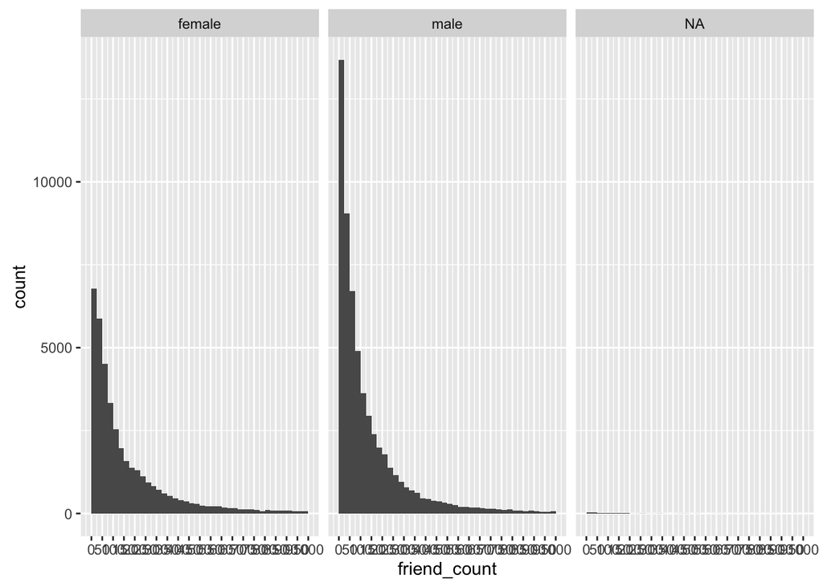

```r
library("ggplot2", lib.loc="/usr/local/lib/R/3.2/site-library")

qplot(x = friend_count, data = pf, binwidth = 25) +
  scale_x_continuous(limits = c(0, 1000), breaks = seq(0, 1000, 50)) +
  facet_wrap(~gender)
```

```r
ggsave("Friend_Count_by_Gender.png", last_plot())
```

```r
by(pf$friend_count, pf$gender, summary)
```

```
FALSE pf$gender: female
FALSE    Min. 1st Qu.  Median    Mean 3rd Qu.    Max.
FALSE       0      37      96     242     244    4923
FALSE --------------------------------------------------------
FALSE pf$gender: male
FALSE    Min. 1st Qu.  Median    Mean 3rd Qu.    Max.
FALSE       0      27      74     165     182    4917
```

Duration on FB

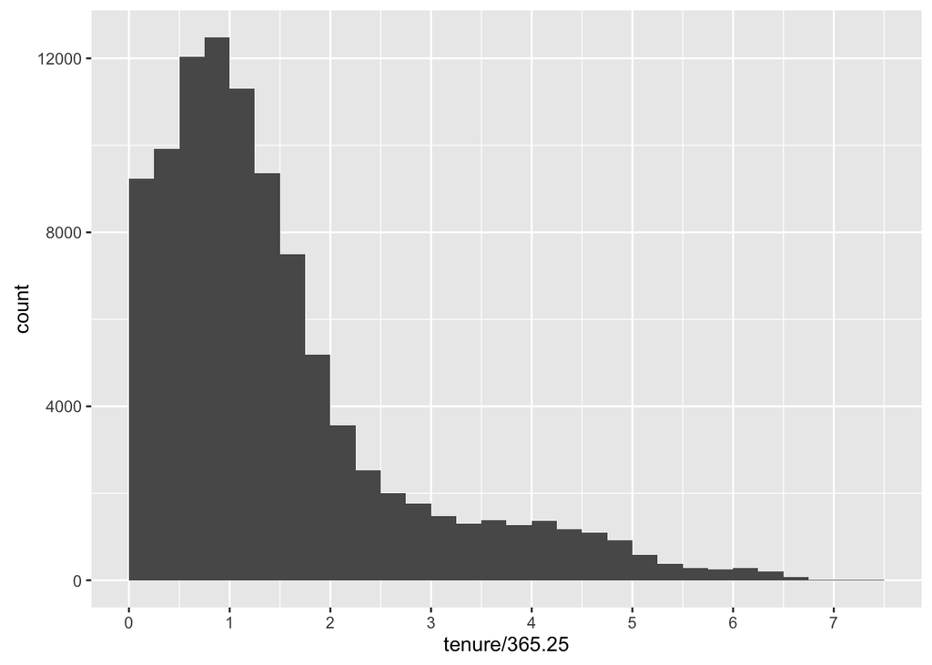

```r
#names(pf)
#str(pf)

qplot(x = tenure/365.25, data = pf, binwidth = 0.25) + scale_x_continuous(lim = c(0, 7.5), breaks = seq(0, 8, 1))
```

```r
ggsave("Duration_on_FB.png", last_plot())
```

Histogram of fb users by age

```r
names(pf)
```

```
FALSE  [1] "userid"                "age"
FALSE  [3] "dob_day"               "dob_year"
FALSE  [5] "dob_month"             "gender"
FALSE  [7] "tenure"                "friend_count"
FALSE  [9] "friendships_initiated" "likes"
FALSE [11] "likes_received"        "mobile_likes"
FALSE [13] "mobile_likes_received" "www_likes"
FALSE [15] "www_likes_received"
```

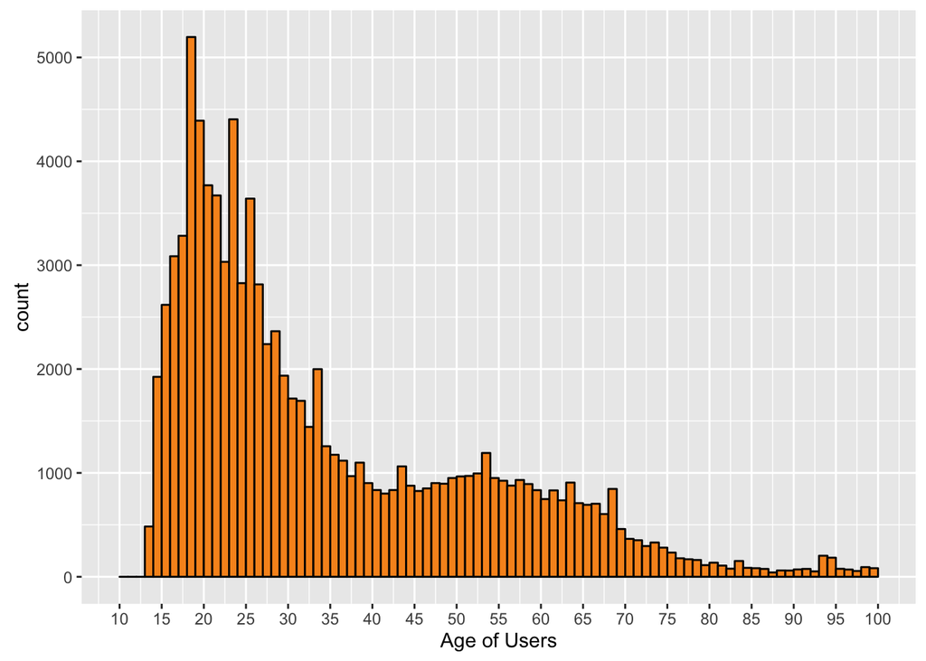

```r
qplot(x = age, data = pf,
      xlab = "Age of Users",
      binwidth = 1,
      color = I('black'), fill = I('#F79420')) +
  scale_x_continuous(lim = c(10, 100), breaks = seq(10, 100, 5))
```

```r
ggsave("AgeofFBusers.png", last_plot())
```

Arranging grid next to each other: USEFUL code!

```r
library("gridExtra", lib.loc="/usr/local/lib/R/3.2/site-library")
library("grid", lib.loc="/usr/local/Cellar/r/3.2.2_1/R.framework/Versions/3.2/Resources/library")

table(pf$friend_count)
```

[output not shown]

[output cut: 288 more lines]

[output not shown]

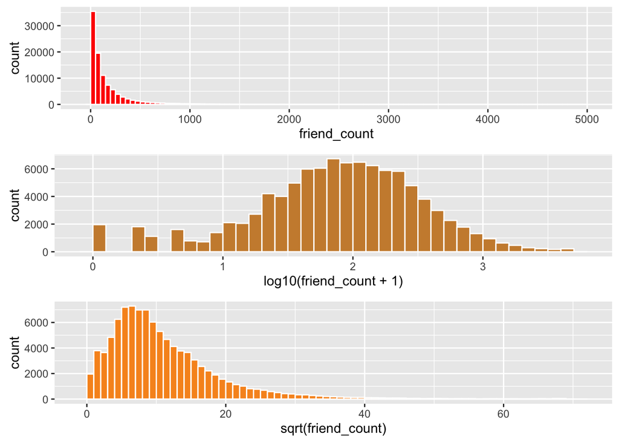

```r
# define individual plots
p1 <- qplot(x = friend_count, data = pf, binwidth = 50, color = I('white'), fill = I('#FF0000'))

p2 <- qplot(x = log10(friend_count + 1), data = pf, binwidth = 0.1, color = I('white'), fill = I('#CC8C3C'))

p3 <- qplot(x = sqrt(friend_count), data = pf, binwidth = 1, color = I('white'), fill = I('#F79421'))

# arrange plots in grid
grid.arrange(p1, p2, p3, ncol=1)
```

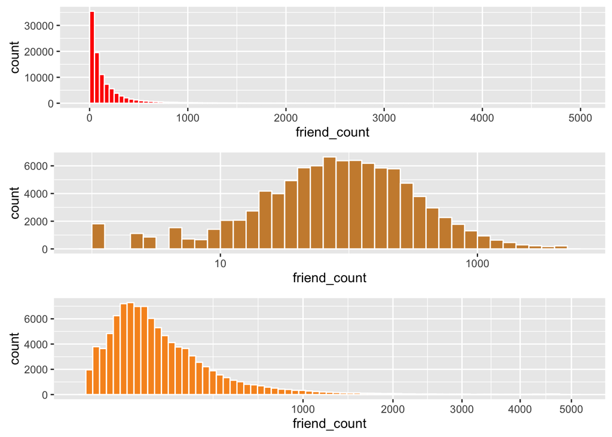

```r
p4 <- qplot(x = friend_count, data = pf, binwidth = 50, color = I('white'), fill = I('#FF0000'))

p5 <- qplot(x = friend_count, data = pf, binwidth = 0.1, color = I('white'), fill = I('#CC8C3C'))  + scale_x_log10()

p6 <- qplot(x = friend_count, data = pf, binwidth = 1, color = I('white'), fill = I('#F79421'))  + scale_x_sqrt()
grid.arrange(p4, p5, p6, ncol=1)
```

```r
ggsave("GridArrange.png", last_plot())
```

Frequency Polygon (practice this more)

```r
#frequency polygon

str(pf)
```

```
FALSE 'data.frame': 99003 obs. of  15 variables:
FALSE  $ userid               : int  2094382 1192601 2083884 1203168 1733186 1524765 1136133 1680361 1365174 1712567 ...
FALSE  $ age                  : int  14 14 14 14 14 14 13 13 13 13 ...
FALSE  $ dob_day              : int  19 2 16 25 4 1 14 4 1 2 ...
FALSE  $ dob_year             : int  1999 1999 1999 1999 1999 1999 2000 2000 2000 2000 ...
FALSE  $ dob_month            : int  11 11 11 12 12 12 1 1 1 2 ...
FALSE  $ gender               : Factor w/ 2 levels "female","male": 2 1 2 1 2 2 2 1 2 2 ...
FALSE  $ tenure               : int  266 6 13 93 82 15 12 0 81 171 ...
FALSE  $ friend_count         : int  0 0 0 0 0 0 0 0 0 0 ...
FALSE  $ friendships_initiated: int  0 0 0 0 0 0 0 0 0 0 ...
FALSE  $ likes                : int  0 0 0 0 0 0 0 0 0 0 ...
FALSE  $ likes_received       : int  0 0 0 0 0 0 0 0 0 0 ...
FALSE  $ mobile_likes         : int  0 0 0 0 0 0 0 0 0 0 ...
FALSE  $ mobile_likes_received: int  0 0 0 0 0 0 0 0 0 0 ...
FALSE  $ www_likes            : int  0 0 0 0 0 0 0 0 0 0 ...
FALSE  $ www_likes_received   : int  0 0 0 0 0 0 0 0 0 0 ...
```

```r
by(pf$www_likes, pf$gender, summary)
```

```
FALSE pf$gender: female
FALSE     Min.  1st Qu.   Median     Mean  3rd Qu.     Max.
FALSE     0.00     0.00     0.00    87.14    25.00 14860.00
FALSE --------------------------------------------------------
FALSE pf$gender: male
FALSE     Min.  1st Qu.   Median     Mean  3rd Qu.     Max.
FALSE     0.00     0.00     0.00    24.42     2.00 12900.00
```

It is clear from the summary that this is a non normal distribution with a long tail (Highly “over dispersed” data).

The summary also shows that for both genders, 50% of users give no www_likes.

Number of Likes by Gender

Demo of the original plot, with no changes.

```r
p7 <- qplot(x = www_likes, data = subset(pf, !is.na(gender)),
            binwidth = 5,
            color = I('white'), fill = I('#FF0000')) +
       scale_x_continuous(name = "www_likes: Original With 0 www_likes",
                          lim = c(0, 400),
                          breaks = seq(0, 400, 50)) +
      facet_wrap(~gender)

ggsave("www_likes_all.png", last_plot())
```

Prep and plot NOT including “0” www_likes and count only those individuals who give likes.

The below graph demonstrates this. I’ve had to cut the x axis to see a clearer representation of the summary.

```r
pf2 <- pf
pf2$www_likes[pf2$www_likes==0] <- NA
table(pf2$www_likes)
```

[output not shown]

[output cut: 234 more lines]

[output not shown]

```r
table(is.na(pf2$www_likes))
```

```
FALSE
FALSE FALSE  TRUE
FALSE 38004 60999
```

```r
table(is.na(pf2$gender))
```

```
FALSE
FALSE FALSE  TRUE
FALSE 98828   175
```

```r
by(pf$www_likes, pf$gender, summary)
```

```
FALSE pf$gender: female
FALSE     Min.  1st Qu.   Median     Mean  3rd Qu.     Max.
FALSE     0.00     0.00     0.00    87.14    25.00 14860.00
FALSE --------------------------------------------------------
FALSE pf$gender: male
FALSE     Min.  1st Qu.   Median     Mean  3rd Qu.     Max.
FALSE     0.00     0.00     0.00    24.42     2.00 12900.00
```

```r
by(pf2$www_likes, pf2$gender, summary)
```

```
FALSE pf2$gender: female
FALSE    Min. 1st Qu.  Median    Mean 3rd Qu.    Max.    NA's
FALSE     1.0     6.0    30.0   183.9   133.0 14860.0   21180
FALSE --------------------------------------------------------
FALSE pf2$gender: male
FALSE    Min. 1st Qu.  Median    Mean 3rd Qu.    Max.    NA's
FALSE       1       3       9      76      39   12900   39755
```

```r
p8 <- qplot(x = www_likes, data = na.omit(pf2),
            binwidth = 5,
            color = I('white'), fill = I('#FF0000')) +
       scale_x_continuous(name = "www_likes: Original Without 0 www_likes",
                          lim = c(0, 400),
                          breaks = seq(0, 400, 50)) +
      facet_wrap(~gender)

ggsave("www_likes_without_0likes.png", last_plot())
```

Transforming the original plot gives a normal - ish distribution.

```r
p9 <- qplot(x = www_likes, data = na.omit(pf2),
            binwidth = 0.1,
            color = I('white'), fill = I('#FF0000'),
            xlab="www_likes: Log10 Transformed") +
      facet_wrap(~gender) +
      scale_x_log10()

ggsave("www_likes_without_0likes_transformed.png", last_plot())
```

Just checking the sqrt plot

```r
p10 <- qplot(x = www_likes, data = na.omit(pf2),
             binwidth = 4,
             color = I('white'), fill = I('#FF0000'),
             xlab = "www_likes: Square Root Transformed") +
      facet_wrap(~gender) +
      scale_x_sqrt()
```

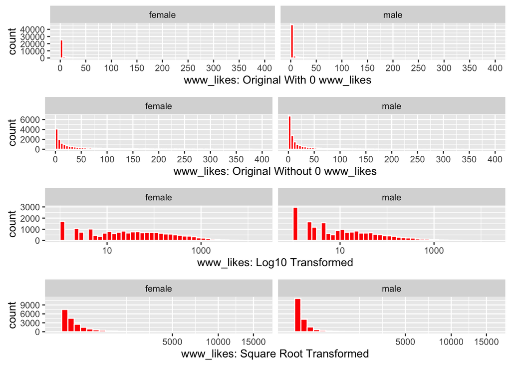

```r
grid.arrange(p7, p8, p9, p10, ncol=1)
```

```r
ggsave("www_likes_vs_gender.png", last_plot())
```

**Conclusion:** Use the log10 transformed graph

Final Overlay

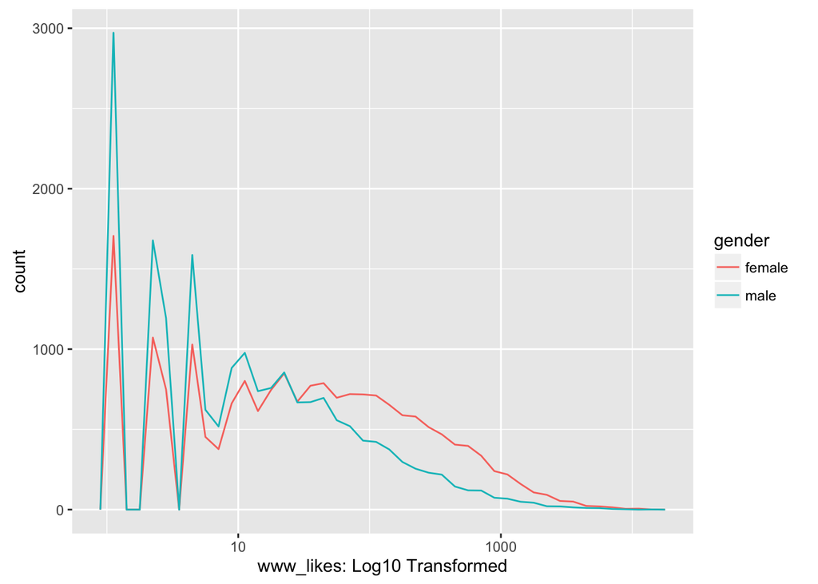

```r
qplot(x = www_likes, data = na.omit(pf2),
      binwidth = 0.1,
      geom = 'freqpoly',
      color = gender,
      xlab="www_likes: Log10 Transformed") +
      scale_x_log10()
```

Just checking what the SqRt Tranformation Gender Overlay would look like

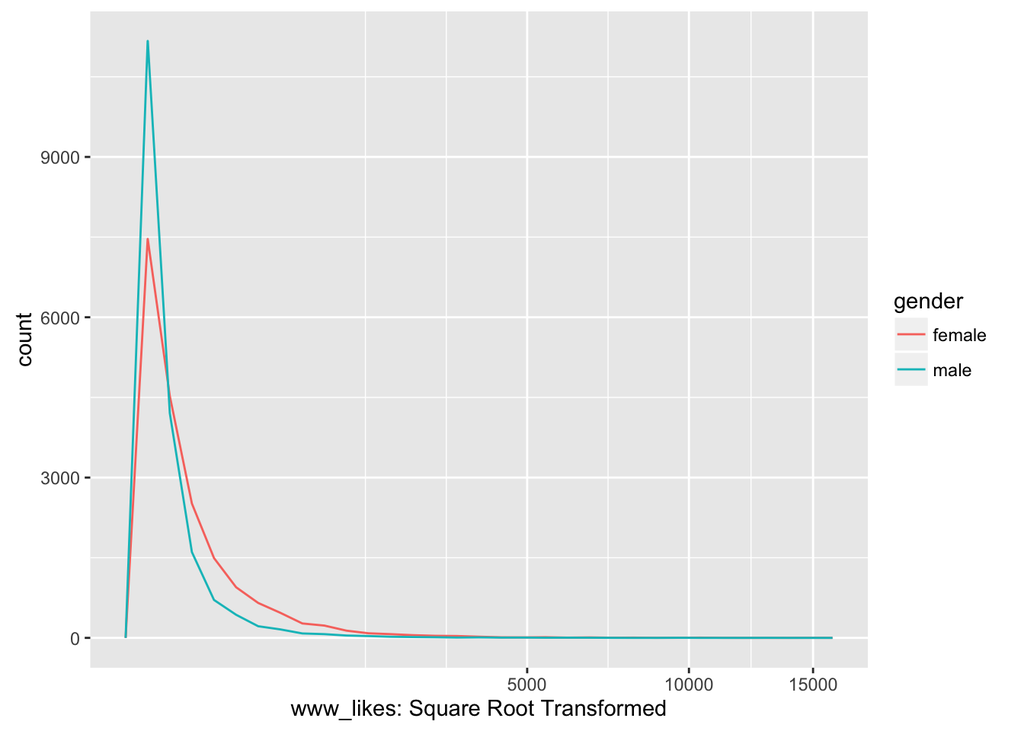

```r
qplot(x = www_likes, data = na.omit(pf2),
    binwidth = 4,
    geom = 'freqpoly',
    color = gender,
    xlab = "www_likes: Square Root Transformed") +
      scale_x_sqrt()
```

Adding up number of fb likes by users, by gender (there’s an easier way to do this below)

```r
library(dplyr)

pf2_males <- filter(pf, gender == "male")

pf2 %>% select (gender) %>% group_by(gender) %>% summarise(count = n())
```

```
FALSE Source: local data frame [3 x 2]
FALSE
FALSE   gender count
FALSE   (fctr) (int)
FALSE 1 female 40254
FALSE 2   male 58574
FALSE 3     NA   175
```

```r
pf2 %>% select (www_likes) %>% group_by(www_likes) %>% summarise(count = n())
```

```
FALSE Source: local data frame [1,726 x 2]
FALSE
FALSE    www_likes count
FALSE        (int) (int)
FALSE 1          1  4697
FALSE 2          2  2760
FALSE 3          3  1948
FALSE 4          4  1419
FALSE 5          5  1202
FALSE 6          6  1081
FALSE 7          7   897
FALSE 8          8   792
FALSE 9          9   757
FALSE 10        10   655
FALSE ..       ...   ...
```

```r
str(pf2_males)
```

```
FALSE 'data.frame': 58574 obs. of  15 variables:
FALSE  $ userid               : int  2094382 2083884 1733186 1524765 1136133 1365174 1712567 1612453 2104073 1918584 ...
FALSE  $ age                  : int  14 14 14 14 13 13 13 13 13 13 ...
FALSE  $ dob_day              : int  19 16 4 1 14 1 2 22 1 5 ...
FALSE  $ dob_year             : int  1999 1999 1999 1999 2000 2000 2000 2000 2000 2000 ...
FALSE  $ dob_month            : int  11 11 12 12 1 1 2 2 2 3 ...
FALSE  $ gender               : Factor w/ 2 levels "female","male": 2 2 2 2 2 2 2 2 2 2 ...
FALSE  $ tenure               : int  266 13 82 15 12 81 171 98 55 106 ...
FALSE  $ friend_count         : int  0 0 0 0 0 0 0 0 0 0 ...
FALSE  $ friendships_initiated: int  0 0 0 0 0 0 0 0 0 0 ...
FALSE  $ likes                : int  0 0 0 0 0 0 0 0 0 0 ...
FALSE  $ likes_received       : int  0 0 0 0 0 0 0 0 0 0 ...
FALSE  $ mobile_likes         : int  0 0 0 0 0 0 0 0 0 0 ...
FALSE  $ mobile_likes_received: int  0 0 0 0 0 0 0 0 0 0 ...
FALSE  $ www_likes            : int  0 0 0 0 0 0 0 0 0 0 ...
FALSE  $ www_likes_received   : int  0 0 0 0 0 0 0 0 0 0 ...
```

```r
pf2_males %>% select(www_likes) %>% colSums()
```

```
FALSE www_likes
FALSE   1430175
```

```r
pf2_females <- filter(pf, gender == "female")
pf2_females %>% select(www_likes) %>% colSums()
```

```
FALSE www_likes
FALSE   3507665
```

Proper way of doing the above chunk… practice the “by”" function!

```r
#key function
by(pf$www_likes, pf$gender, sum)
```

```
FALSE pf$gender: female
FALSE [1] 3507665
FALSE --------------------------------------------------------
FALSE pf$gender: male
FALSE [1] 1430175
```

Friend count by gender

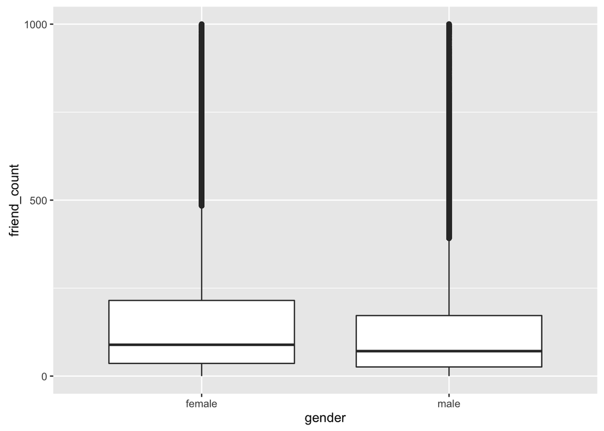

```r
qplot(x = gender, y = friend_count,
      data = subset(pf, !is.na(gender)),
      geom = 'boxplot') + #, ylim = c(0,1000)) +
      scale_y_continuous(lim = c(0, 1000), breaks = seq(0, 1000, 500))
```

```r
#you could also use the ylim function or the coord cartesian layer..
#Coord cartesian matches the below summary stats exactly, as opposed to the scale_y_continuous or ylim.

by(pf$friend_count, pf$gender, summary)
```

```
FALSE pf$gender: female
FALSE    Min. 1st Qu.  Median    Mean 3rd Qu.    Max.
FALSE       0      37      96     242     244    4923
FALSE --------------------------------------------------------
FALSE pf$gender: male
FALSE    Min. 1st Qu.  Median    Mean 3rd Qu.    Max.
FALSE       0      27      74     165     182    4917
```

Friend requests by gender

```r
#str(pf)

#table(is.na(pf$friendships_initiated)) #no NA

by(pf$friendships_initiated, pf$gender, summary)
```

```
FALSE pf$gender: female
FALSE    Min. 1st Qu.  Median    Mean 3rd Qu.    Max.
FALSE     0.0    19.0    49.0   113.9   124.8  3654.0
FALSE --------------------------------------------------------
FALSE pf$gender: male
FALSE    Min. 1st Qu.  Median    Mean 3rd Qu.    Max.
FALSE     0.0    15.0    44.0   103.1   111.0  4144.0
```

```r
by(pf$friendships_initiated, pf$gender, sum)
```

```
FALSE pf$gender: female
FALSE [1] 4584894
FALSE --------------------------------------------------------
FALSE pf$gender: male
FALSE [1] 6037023
```

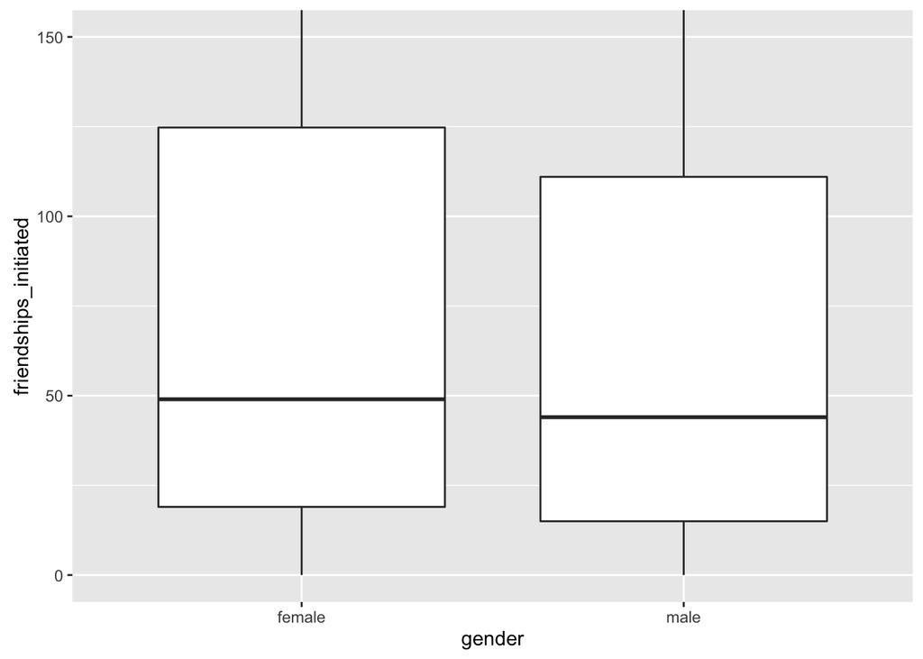

```r
qplot(x = gender, y = friendships_initiated,
      data = subset(pf, !is.na(gender)),
      geom = 'boxplot') + #, ylim = c(0,1000)) +
      coord_cartesian(ylim=c(0,150))
```

```r
ggsave("FriendReq_byGender.png", last_plot())
```

```r
#str(pf)
#table(pf$mobile_likes)
table(is.na(pf$mobile_likes))
```

```
FALSE
FALSE FALSE
FALSE 99003
```